# Assigning with DADA2

Liangzi

2025-03-07

# Set up the encironment

## Set Seed

```r
# Set the seed for reproducibility
set.seed(238428)
# Let's make a parameter to set the number of threads
n_threads = 20
```

#Timing of this script

```r
# What time did we start running this script?
start_time <- Sys.time()
```

## Load Packages

```r
pacman::p_load(tidyverse, devtools, dada2,
               patchwork, DT, install = FALSE)
```

# Load Filtered Fastq Files

```r
# Place filtered seq into a variable
filtered_fastqs_path <- "/local/workdir/lz592/MyProject/data/02_filtered_fastqs/"

# Intuition Check
filtered_fastqs_path
```

```
## [1] "/local/workdir/lz592/MyProject/data/02_filtered_fastqs/"
```

```r
# Create Forward vector
filtered_forward_reads <-
  list.files(filtered_fastqs_path, pattern = "1_filtered.fastq.gz",
             full.names = TRUE)
# Check
filtered_forward_reads[1:5]
```

```
## [1] "/local/workdir/lz592/MyProject/data/02_filtered_fastqs//SRR12873300_1_filtered.fastq.gz"
## [2] "/local/workdir/lz592/MyProject/data/02_filtered_fastqs//SRR12873301_1_filtered.fastq.gz"
## [3] "/local/workdir/lz592/MyProject/data/02_filtered_fastqs//SRR12873302_1_filtered.fastq.gz"
## [4] "/local/workdir/lz592/MyProject/data/02_filtered_fastqs//SRR12873303_1_filtered.fastq.gz"
## [5] "/local/workdir/lz592/MyProject/data/02_filtered_fastqs//SRR12873304_1_filtered.fastq.gz"
```

```r
# Reverse vector
filtered_reverse_reads <-
    list.files(filtered_fastqs_path, pattern = "2_filtered.fastq.gz",
             full.names = TRUE)
# Check
filtered_reverse_reads[1:5]
```

```
## [1] "/local/workdir/lz592/MyProject/data/02_filtered_fastqs//SRR12873300_2_filtered.fastq.gz"
## [2] "/local/workdir/lz592/MyProject/data/02_filtered_fastqs//SRR12873301_2_filtered.fastq.gz"
## [3] "/local/workdir/lz592/MyProject/data/02_filtered_fastqs//SRR12873302_2_filtered.fastq.gz"
## [4] "/local/workdir/lz592/MyProject/data/02_filtered_fastqs//SRR12873303_2_filtered.fastq.gz"
## [5] "/local/workdir/lz592/MyProject/data/02_filtered_fastqs//SRR12873304_2_filtered.fastq.gz"
```

# Sample Name

```r
# Create vector of sample names from the filenames
sample_names <- sapply(strsplit(basename(filtered_forward_reads), "_"), `[`,1)

# Intuition Check
head(sample_names)
```

```
## [1] "SRR12873300" "SRR12873301" "SRR12873302" "SRR12873303" "SRR12873304"
## [6] "SRR12873305"
```

# Error Modelling

```r
# Forward Reads
error_forward_reads <-
  learnErrors(filtered_forward_reads, multithread = n_threads)
```

```
## 105138792 total bases in 398253 reads from 11 samples will be used for learning the error rates.
```

```r
# Forward Error Plot
forward_error_plot <-
  plotErrors(error_forward_reads, nominalQ = TRUE) +
  labs(title = "Forward Reads: Error Model")

# Reverse Reads
error_reverse_reads <-
  learnErrors(filtered_reverse_reads, multithread = n_threads)
```

```
## 105899730 total bases in 557367 reads from 19 samples will be used for learning the error rates.
```

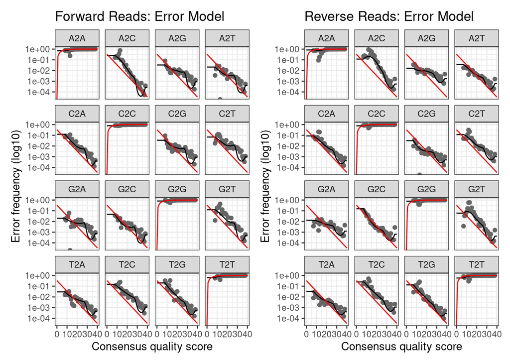

```r
# Reverse Error Plot
reverse_error_plot <-
  plotErrors(error_reverse_reads, nominalQ = TRUE) +
  labs(title = "Reverse Reads: Error Model")

# Put the two plots together
forward_error_plot + reverse_error_plot
```

# Infer ASVs

```r
# Infer ASVs on the forward sequences
dada_forward <-
  dada(filtered_forward_reads,
       err = error_forward_reads,
       multithread = n_threads)
```

```
## Sample 1 - 58565 reads in 8246 unique sequences.
## Sample 2 - 41736 reads in 3894 unique sequences.
## Sample 3 - 37616 reads in 5411 unique sequences.
## Sample 4 - 50362 reads in 4692 unique sequences.
## Sample 5 - 46870 reads in 4552 unique sequences.
## Sample 6 - 42415 reads in 6808 unique sequences.
## Sample 7 - 42930 reads in 4241 unique sequences.
## Sample 8 - 18654 reads in 3679 unique sequences.
## Sample 9 - 17344 reads in 4693 unique sequences.
## Sample 10 - 21020 reads in 3781 unique sequences.
## Sample 11 - 20741 reads in 4968 unique sequences.
## Sample 12 - 12913 reads in 5693 unique sequences.
## Sample 13 - 12300 reads in 1286 unique sequences.
## Sample 14 - 12794 reads in 1713 unique sequences.
## Sample 15 - 13835 reads in 2592 unique sequences.
## Sample 16 - 21081 reads in 3479 unique sequences.
## Sample 17 - 41908 reads in 4745 unique sequences.
## Sample 18 - 9240 reads in 1100 unique sequences.
## Sample 19 - 35043 reads in 9192 unique sequences.
## Sample 20 - 57486 reads in 13489 unique sequences.
## Sample 21 - 45857 reads in 11842 unique sequences.
## Sample 22 - 40371 reads in 5673 unique sequences.
## Sample 23 - 48962 reads in 3854 unique sequences.
## Sample 24 - 42131 reads in 4449 unique sequences.
## Sample 25 - 52272 reads in 5477 unique sequences.
## Sample 26 - 39835 reads in 4855 unique sequences.
## Sample 27 - 58450 reads in 9535 unique sequences.
## Sample 28 - 42950 reads in 4616 unique sequences.
## Sample 29 - 49115 reads in 7007 unique sequences.
```

```r
# Take a look at the data
typeof(dada_forward)
```

```
## [1] "list"
```

```r
dada_forward
```

```
## $SRR12873300_1_filtered.fastq.gz
## dada-class: object describing DADA2 denoising results
## 340 sequence variants were inferred from 8246 input unique sequences.
## Key parameters: OMEGA_A = 1e-40, OMEGA_C = 1e-40, BAND_SIZE = 16
##
## $SRR12873301_1_filtered.fastq.gz
## dada-class: object describing DADA2 denoising results
## 205 sequence variants were inferred from 3894 input unique sequences.
## Key parameters: OMEGA_A = 1e-40, OMEGA_C = 1e-40, BAND_SIZE = 16
##
## $SRR12873302_1_filtered.fastq.gz
## dada-class: object describing DADA2 denoising results
## 265 sequence variants were inferred from 5411 input unique sequences.
## Key parameters: OMEGA_A = 1e-40, OMEGA_C = 1e-40, BAND_SIZE = 16
##
## $SRR12873303_1_filtered.fastq.gz
## dada-class: object describing DADA2 denoising results
## 237 sequence variants were inferred from 4692 input unique sequences.
## Key parameters: OMEGA_A = 1e-40, OMEGA_C = 1e-40, BAND_SIZE = 16
##
## $SRR12873304_1_filtered.fastq.gz
## dada-class: object describing DADA2 denoising results
## 266 sequence variants were inferred from 4552 input unique sequences.
## Key parameters: OMEGA_A = 1e-40, OMEGA_C = 1e-40, BAND_SIZE = 16
##
## $SRR12873305_1_filtered.fastq.gz
## dada-class: object describing DADA2 denoising results
## 368 sequence variants were inferred from 6808 input unique sequences.
## Key parameters: OMEGA_A = 1e-40, OMEGA_C = 1e-40, BAND_SIZE = 16
##
## $SRR12873306_1_filtered.fastq.gz
## dada-class: object describing DADA2 denoising results
## 273 sequence variants were inferred from 4241 input unique sequences.
## Key parameters: OMEGA_A = 1e-40, OMEGA_C = 1e-40, BAND_SIZE = 16
##
## $SRR12873307_1_filtered.fastq.gz
## dada-class: object describing DADA2 denoising results
## 305 sequence variants were inferred from 3679 input unique sequences.
## Key parameters: OMEGA_A = 1e-40, OMEGA_C = 1e-40, BAND_SIZE = 16
##
```

[output cut: 89 more lines]

```
##
## $SRR12873326_1_filtered.fastq.gz
## dada-class: object describing DADA2 denoising results
## 409 sequence variants were inferred from 9535 input unique sequences.
## Key parameters: OMEGA_A = 1e-40, OMEGA_C = 1e-40, BAND_SIZE = 16
##
## $SRR12873327_1_filtered.fastq.gz
## dada-class: object describing DADA2 denoising results
## 260 sequence variants were inferred from 4616 input unique sequences.
## Key parameters: OMEGA_A = 1e-40, OMEGA_C = 1e-40, BAND_SIZE = 16
##
## $SRR12873328_1_filtered.fastq.gz
## dada-class: object describing DADA2 denoising results
## 442 sequence variants were inferred from 7007 input unique sequences.
## Key parameters: OMEGA_A = 1e-40, OMEGA_C = 1e-40, BAND_SIZE = 16
```

```r
length(dada_forward)
```

```
## [1] 29
```

```r
# What does it look like for each sample?
dada_forward$`SRR12873302_1_filtered.fastq.gz`
```

```
## dada-class: object describing DADA2 denoising results
## 265 sequence variants were inferred from 5411 input unique sequences.
## Key parameters: OMEGA_A = 1e-40, OMEGA_C = 1e-40, BAND_SIZE = 16
```

```r
# Reverse ASVs
dada_reverse <- dada(filtered_reverse_reads,
                     err = error_reverse_reads,
                     multithread = n_threads)
```

```
## Sample 1 - 58565 reads in 10642 unique sequences.
## Sample 2 - 41736 reads in 6076 unique sequences.
## Sample 3 - 37616 reads in 7863 unique sequences.
## Sample 4 - 50362 reads in 7026 unique sequences.
## Sample 5 - 46870 reads in 6684 unique sequences.
## Sample 6 - 42415 reads in 9609 unique sequences.
## Sample 7 - 42930 reads in 6797 unique sequences.
## Sample 8 - 18654 reads in 3772 unique sequences.
## Sample 9 - 17344 reads in 4415 unique sequences.
## Sample 10 - 21020 reads in 3767 unique sequences.
## Sample 11 - 20741 reads in 4832 unique sequences.
## Sample 12 - 12913 reads in 5182 unique sequences.
## Sample 13 - 12300 reads in 1735 unique sequences.
## Sample 14 - 12794 reads in 2306 unique sequences.
## Sample 15 - 13835 reads in 3089 unique sequences.
## Sample 16 - 21081 reads in 4378 unique sequences.
## Sample 17 - 41908 reads in 6497 unique sequences.
## Sample 18 - 9240 reads in 1353 unique sequences.
## Sample 19 - 35043 reads in 12460 unique sequences.
## Sample 20 - 57486 reads in 17367 unique sequences.
## Sample 21 - 45857 reads in 15270 unique sequences.
## Sample 22 - 40371 reads in 9480 unique sequences.
## Sample 23 - 48962 reads in 6699 unique sequences.
## Sample 24 - 42131 reads in 6912 unique sequences.
## Sample 25 - 52272 reads in 8354 unique sequences.
## Sample 26 - 39835 reads in 6695 unique sequences.
## Sample 27 - 58450 reads in 12840 unique sequences.
## Sample 28 - 42950 reads in 6829 unique sequences.
## Sample 29 - 49115 reads in 10512 unique sequences.
```

```r
# Check data
dada_reverse[30]
```

```
## $<NA>
## NULL
```

# Merge Forward and Reverse ASVs

```r
merged_ASVs <-
  mergePairs(dada_forward, filtered_forward_reads,
             dada_reverse, filtered_reverse_reads,
             verbose = TRUE)
```

```
## 54391 paired-reads (in 1997 unique pairings) successfully merged out of 57051 (in 3576 pairings) input.
```

```
## 40961 paired-reads (in 265 unique pairings) successfully merged out of 41415 (in 330 pairings) input.
```

```
## 34860 paired-reads (in 653 unique pairings) successfully merged out of 36505 (in 1587 pairings) input.
```

```
## 49779 paired-reads (in 306 unique pairings) successfully merged out of 50063 (in 407 pairings) input.
```

```
## 46145 paired-reads (in 351 unique pairings) successfully merged out of 46499 (in 514 pairings) input.
```

```
## 38585 paired-reads (in 729 unique pairings) successfully merged out of 41022 (in 2369 pairings) input.
```

```
## 42384 paired-reads (in 389 unique pairings) successfully merged out of 42695 (in 437 pairings) input.
```

```
## 17820 paired-reads (in 306 unique pairings) successfully merged out of 18155 (in 448 pairings) input.
```

```
## 15124 paired-reads (in 201 unique pairings) successfully merged out of 16004 (in 507 pairings) input.
```

```
## 20192 paired-reads (in 242 unique pairings) successfully merged out of 20425 (in 313 pairings) input.
```

```
## 18899 paired-reads (in 315 unique pairings) successfully merged out of 19575 (in 549 pairings) input.
```

```
## 73 paired-reads (in 10 unique pairings) successfully merged out of 11990 (in 2905 pairings) input.
```

```
## 0 paired-reads (in 0 unique pairings) successfully merged out of 12232 (in 152 pairings) input.
```

```
## 56 paired-reads (in 4 unique pairings) successfully merged out of 12777 (in 16 pairings) input.
```

```
## 92 paired-reads (in 11 unique pairings) successfully merged out of 13588 (in 355 pairings) input.
```

```
## 145 paired-reads (in 7 unique pairings) successfully merged out of 20906 (in 265 pairings) input.
```

```
## 41255 paired-reads (in 440 unique pairings) successfully merged out of 41574 (in 501 pairings) input.
```

```
## 28 paired-reads (in 5 unique pairings) successfully merged out of 9201 (in 53 pairings) input.
```

```
## 27967 paired-reads (in 862 unique pairings) successfully merged out of 32735 (in 3946 pairings) input.
```

```
## 49266 paired-reads (in 2441 unique pairings) successfully merged out of 54885 (in 5952 pairings) input.
```

```
## 37622 paired-reads (in 1594 unique pairings) successfully merged out of 43071 (in 5169 pairings) input.
```

```
## 38836 paired-reads (in 474 unique pairings) successfully merged out of 39638 (in 797 pairings) input.
```

```
## 48495 paired-reads (in 261 unique pairings) successfully merged out of 48744 (in 332 pairings) input.
```

```
## 41375 paired-reads (in 396 unique pairings) successfully merged out of 41739 (in 436 pairings) input.
```

```
## 51263 paired-reads (in 458 unique pairings) successfully merged out of 51853 (in 514 pairings) input.
```

```
## 39268 paired-reads (in 464 unique pairings) successfully merged out of 39599 (in 543 pairings) input.
```

```
## 52472 paired-reads (in 1460 unique pairings) successfully merged out of 56574 (in 3990 pairings) input.
```

```
## 42155 paired-reads (in 333 unique pairings) successfully merged out of 42622 (in 513 pairings) input.
```

```
## 45794 paired-reads (in 687 unique pairings) successfully merged out of 47878 (in 1998 pairings) input.
```

```r
# Evaluate the data output
typeof(merged_ASVs)
```

```
## [1] "list"
```

```r
length(merged_ASVs)
```

```
## [1] 29
```

```r
head(names(merged_ASVs)) # Access our current sample names
```

```
## [1] "SRR12873300_1_filtered.fastq.gz" "SRR12873301_1_filtered.fastq.gz"
## [3] "SRR12873302_1_filtered.fastq.gz" "SRR12873303_1_filtered.fastq.gz"
## [5] "SRR12873304_1_filtered.fastq.gz" "SRR12873305_1_filtered.fastq.gz"
```

```r
# Inspect further: Inspect the whole merger data.frame
head(merged_ASVs)
```

```
## $SRR12873300_1_filtered.fastq.gz
##                                                                                                                                                                                                                                                                                                          …
## 1      CCGCGGTAATACGGAGGGTGCAAGCGTTAATCGGAATTACTGGGCGTAAAGCGTGCGTAG…
## 2      CCGCGGTAATACGGAGGGTGCAAGCGTTAATCGGAATTACTGGGCGTAAAGCGTGCGTAG…
## 3      CCGCGGTAATACGGAGGGTGCAAGCGTTAATCGGAATTACTGGGCGTAAAGCGTGCGTAG…
## 4      CCGCGGTAATACGGAGGGTGCAAGCGTTAATCGGAATTACTGGGCGTAAAGCGTGCGTAG…
## 5      CCGCGGTAATACGAAGGGTGCAAGCGTTACTCGGAATTACTGGGCGTAAAGCGTGCGTAG…
## 6          CCGCGGTAATACGGAGGGTGCAAGCGTTATCCGGATTTATTGGGTTTAAAGGGTCCGTAG…
## 7      CCGCGGTAATACGAAGGGTGCAAGCGTTACTCGGAATTACTGGGCGTAAAGCGTGCGTAG…
## 8          CCGCGGTAATACGGAGGGTGCAAGCGTTATCCGGATTTATTGGGTTTAAAGGGTCCGTAG…
## 9       CCGCGGTAATACGAGGGGAGCTAGCGTTGTTCGGAATTACTGGGCGTAAAGCGCGCGTAG…
## 10       CCGCGGTAATACGTAGGGTGCAAGCGTTAATCGGAATTACTGGGCGTAAAGCGTGCGCAG…
## 11      CCGCGGTAATACGAGGGGAGCTAGCGTTGTTCGGAATTACTGGGCGTAAAGCGCGCGTAG…
## 12       CCGCGGTAATACGTAGGGTGCAAGCGTTAATCGGAATTACTGGGCGTAAAGCGTGCGCAG…
## 13     CCGCGGTAATACGAAGGGTGCAAGCGTTACTCGGAATTACTGGGCGTAAAGCGTGCGTAG…
```

[output cut: 8610 more lines]

```r
# Inspect further for each sample
#head(merged_ASVs, n = 2) # A dataframe for each sample
# We have a dataframe in each part of our list! What are in the columns?
glimpse(merged_ASVs$`SRR12873303_1_filtered.fastq.gz`)
```

```
## Rows: 306
## Columns: 9
## $ sequence  <chr> "CCGCGGTAATACGTAGGGTGCGAGCGTTAATCGGAATTACTGGGCGTAAAGCGTGCGCA…
## $ abundance <int> 9232, 6470, 2428, 2358, 1991, 1943, 1846, 1713, 1366, 1319, …
## $ forward   <int> 1, 1, 3, 2, 4, 5, 2, 3, 5, 4, 6, 7, 6, 9, 7, 10, 8, 12, 9, 1…
## $ reverse   <int> 1, 2, 4, 3, 7, 6, 5, 8, 9, 10, 11, 15, 13, 16, 18, 12, 19, 1…
## $ nmatch    <int> 67, 67, 67, 65, 67, 66, 65, 67, 66, 67, 66, 61, 66, 67, 61, …
## $ nmismatch <int> 0, 0, 0, 0, 0, 0, 0, 0, 0, 0, 0, 0, 0, 0, 0, 0, 0, 0, 0, 0, …
## $ nindel    <int> 0, 0, 0, 0, 0, 0, 0, 0, 0, 0, 0, 0, 0, 0, 0, 0, 0, 0, 0, 0, …
## $ prefer    <dbl> 1, 1, 1, 1, 1, 1, 1, 1, 1, 1, 1, 1, 1, 1, 1, 2, 1, 1, 1, 2, …
## $ accept    <lgl> TRUE, TRUE, TRUE, TRUE, TRUE, TRUE, TRUE, TRUE, TRUE, TRUE, …
```

# Create Raw ASV Count Table

```r
raw_ASV_table <- makeSequenceTable(merged_ASVs)

# Check the type and dimensions of the data
dim(raw_ASV_table)
```

```
## [1]    29 10586
```

```r
typeof(raw_ASV_table)
```

```
## [1] "integer"
```

```r
class(raw_ASV_table)
```

```
## [1] "matrix" "array"
```

```r
# Write out the file 'raw_ASV_table' to data/01_DADA2/
write.table(raw_ASV_table, file = "data/raw_ASV_counts.tsv",
            sep = "\t", quote = FALSE, col.names = NA)
```

# Assess ASV Quality

## What are the current ASV lengths?

*1. The sequencing strategy* - Paired-end (2x300bp) Illumina MiSeq Sequencing was used. - Specifically, the V4 hypervariable region of the 16S rRNA gene was targeted for sequencing with the 515F and 907R primers. *2. The total length of starting amplicons* - Our primers are named after the location they bind to on the 16S gene. So: 907 - 515 = 392 bp - The total length of the starting amplicon is 392 base pairs, with primers. *3. What is the ASV length without primers?* The 515F (5’-GTGCCAGCMGCCGCGG-3’) primer is 16 base pairs. The 907R (5’-CCGTCAATTCMTTTRAGTTT-3’) primer is 20 base pairs. 392 - 16 - 20 = 356 bp The expected ASV length without primers is 356 base pairs. *4. The length expected after the filterAndTrim() step* In my 01_QualityTrimming.Rmd, I used trimLeft = (16,20) to remove 16 bases at the beginning of the forward read and 20 bases at the beginning of the revere read, and truncLen = c(280, 210), which removed 20 bases at the end of the forward read and 90 bases at the end of the reverse read. Therefore, the length expected after the filterAndTrim() step is 356 bp. *5. The expected percent overlap* The author performed 2x300 paired-end Illumina MiSeq Sequencing. However, from the multiQC report, we can see that the read length is actually 301 bp. If we have a total read length of 301 base pairs and we did not sequence our primers, then the overlap should be ~100%.

# ASV Length Stats

```r
# Calculate summary stats
# Longest ASV?
maxLength_ASV <- max(nchar(getSequences(raw_ASV_table)))

# Shortest ASV?
minLength_ASV <- min(nchar(getSequences(raw_ASV_table)))

# Mean ASV length?
meanLength_ASV <- mean(nchar(getSequences(raw_ASV_table)))

# Median ASV length?
medianLength_ASV <- median(nchar(getSequences(raw_ASV_table)))

# Create a table to Inspect the distribution of sequence lengths of all ASVs in dataset
table(nchar(getSequences(raw_ASV_table)))
```

```
##
##  264  266  274  277  286  287  288  299  303  304  305  308  309  310  311  312
##   47    8    2    2    1    1    2    5    1    2  295   21  205    1  180   25
##  313  314  315  316  317  318  321  323  326  327  329  335  336  345  347  364
##    1   37   52    1   26    4    1   36    1   16   22    1    1    2    5    2
##  368  376  379  380  381  382  383  384  385  386  387  388  389  390  391  392
##    2    1    4    4    6   34  116   52 1077  401 2645 1517 3476  154   40   18
##  393  394  396  407  412  420  425  426  435  441
##   21    3    1    1    2    1    1    1    1    1
```

### ASV Length Plot

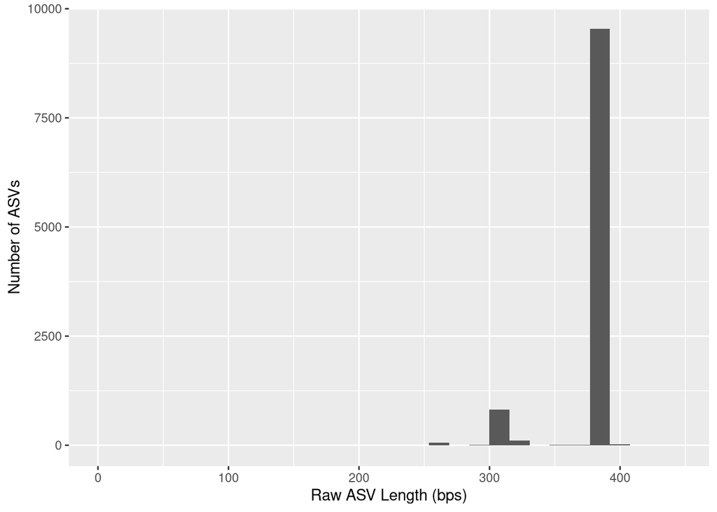

```r
# Inspect the distribution of sequence lengths of all ASVs in data set
# AFTER TRIM
plot_ASVLength_raw <-
  data.frame(Seq_Length = nchar(getSequences(raw_ASV_table))) %>%
  ggplot(aes(x = Seq_Length )) +
  geom_histogram() +
  # include the x-axis scales
  scale_x_continuous(limits = c(0, maxLength_ASV + 5)) +
  labs(y = "Number of ASVs", x = "Raw ASV Length (bps)")

# Show the plot
plot_ASVLength_raw
```

**INTERPRETATION #2:** *Does the ASV length data (table and plot above) match your hypotheses from INTERPRETATION #1? Why or why not? Please insert a description of the interpretation you draw regarding the lengths of your ASVs that you’ve inferred from the ASV length table and it’s graphical visualization above.* As we saw in the table, the length of the ASVs is mostly ~385-389 base pairs. The histogram also shows a strong peak around ~385-389 bp. Interpretation: The observed ASV lengths are longer than expected (385-389 bp vs. Expected 356 bp). Therefore, the ASV length data (table and plot) does not fully match my hypotheses from INTERPRETATION #1. This suggests that additional trimming may be necessary or that some sequences contain artifacts that need further filtering. The reasons for that might be: 1) The observed ASV lengths suggest that some sequences may still contain primer remnants; 2) If overlapping regions were imperfectly merged, some reads may have retained additional bases; 3) Some of the longer ASVs could be due to chimeric sequences that were not fully removed.

**INTERPRETATION #3:** *Taking into account INTERPRETATIONS #1 and #2, what is your suggested trimming procedure for your ASV lengths? Will you allow some variation or trim to an exact length, similar to our in class example here?* Explicitly trim primers before filterAndTrim(); adjust truncLen values to the the expected ASV length length while allowing some variation; check the new ASV length distribution post-filtering to confirm improvements.

# Trim ASV lengths

```r
# Subset only ASVs that are 385-389 bps long
raw_ASV_table_trimmed <-
  raw_ASV_table[,nchar(colnames(raw_ASV_table)) %in% 385:389]

# Inspect the distribution of sequence lengths of all ASVs in dataset
table(nchar(getSequences(raw_ASV_table_trimmed)))
```

```
##
##  385  386  387  388  389
## 1077  401 2645 1517 3476
```

```r
# What proportion of total ASV sequences are left in the data?
percRetained_Trimmed <- sum(raw_ASV_table_trimmed)/sum(raw_ASV_table)
percRetained_Trimmed # Show it
```

```
## [1] 0.8766327
```

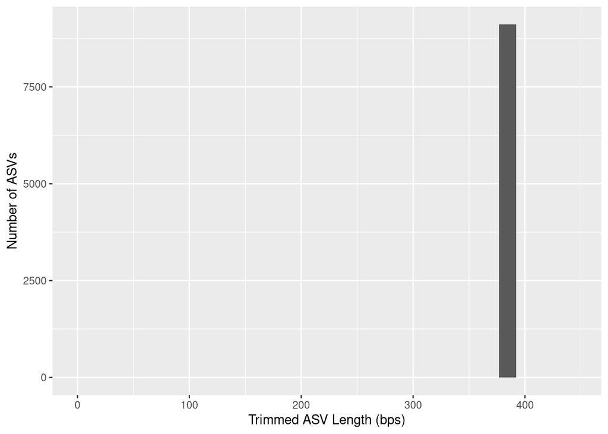

```r
# Inspect the distribution of sequence lengths of all ASVs in dataset
# AFTER TRIM
plot_ASVLength_trimmed <-
  data.frame(Seq_Length = nchar(getSequences(raw_ASV_table_trimmed))) %>%
  ggplot(aes(x = Seq_Length )) +
  geom_histogram() +
  # include the x-axis scales
  scale_x_continuous(limits = c(0, maxLength_ASV + 5)) +
  labs(y = "Number of ASVs", x = "Trimmed ASV Length (bps)")

# Show the plot
plot_ASVLength_trimmed
```

# Remove Chimeras

```r
# Remove the chimeras in the raw ASV table
noChimeras_ASV_table <-
  removeBimeraDenovo(raw_ASV_table_trimmed,
                     method="consensus",
                     multithread = n_threads,
                     verbose=TRUE)
```

```
## Identified 7123 bimeras out of 9116 input sequences.
```

```r
# Check the dimensions
dim(noChimeras_ASV_table)
```

```
## [1]   29 1993
```

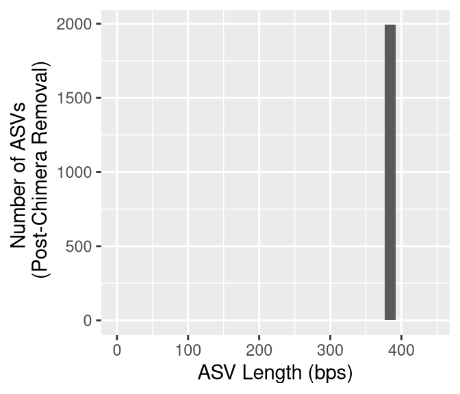

```r
# What proportion is left of the sequences?
# Chimera removal compared to trimming
percRetained_chimerasTrimmed <- sum(noChimeras_ASV_table)/sum(raw_ASV_table_trimmed)
# Chimera removal compared to raw
percRetained_chimerasRaw <-sum(noChimeras_ASV_table)/sum(raw_ASV_table)

# Plot it
plot_ASVLength_NoChimeras <-
  data.frame(Seq_Length_NoChim = nchar(getSequences(noChimeras_ASV_table))) %>%
  ggplot(aes(x = Seq_Length_NoChim )) +
  geom_histogram()+
  # include the x-axis scales
  scale_x_continuous(limits = c(0, maxLength_ASV + 5)) +
  labs(y = "Number of ASVs \n (Post-Chimera Removal)",
       x = "ASV Length (bps)")

# Show the plot
plot_ASVLength_NoChimeras
```

# Plot ASV Lengths

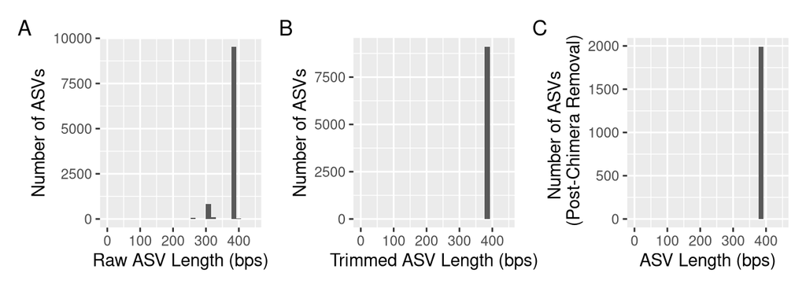

```r
plot_ASVLength_raw + plot_ASVLength_trimmed + plot_ASVLength_NoChimeras +
    plot_annotation(tag_levels = 'A')
```

# Track the read counts

```r
# A little function to identify number seqs
getN <- function(x) sum(getUniques(x))

# Make the table to track the seqs
track <- cbind(sapply(dada_forward, getN),
               sapply(dada_reverse, getN),
               sapply(merged_ASVs, getN),
               rowSums(noChimeras_ASV_table))

head(track)
```

```
##                                  [,1]  [,2]  [,3]  [,4]
## SRR12873300_1_filtered.fastq.gz 57716 57831 54391 38538
## SRR12873301_1_filtered.fastq.gz 41674 41470 40961 37503
## SRR12873302_1_filtered.fastq.gz 37107 36917 34860 29227
## SRR12873303_1_filtered.fastq.gz 50249 50156 49779 47436
## SRR12873304_1_filtered.fastq.gz 46748 46595 46145 45069
## SRR12873305_1_filtered.fastq.gz 41728 41582 38585 33693
```

```r
# Update column names to be more informative (most are missing at the moment!)
colnames(track) <- c("denoisedF", "denoisedR", "merged", "nochim")
rownames(track) <- row.names(noChimeras_ASV_table)

# Generate a dataframe to track the reads through our DADA2 pipeline
track_counts_df <-
  track %>%
  # make it a dataframe
  as.data.frame() %>%
  rownames_to_column(var = "sample_names")

# Now let's add a column for the number of ASVs
# First, intuition check that the samples match
stopifnot(track_counts_df$sample_names == row.names(noChimeras_ASV_table))

# Now, let's add a new column with the number of ASVs
track_counts_df <-
  track_counts_df %>%
  mutate(num_ASVs = rowSums(noChimeras_ASV_table > 1))

# Visualize it in table format
DT::datatable(track_counts_df)
```

|  | sample_names | denoisedF | denoisedR | merged | nochim | num_ASVs |
| --- | --- | --- | --- | --- | --- | --- |
| 1 | SRR12873300_1_filtered.fastq.gz | 57716 | 57831 | 54391 | 38538 | 149 |
| 2 | SRR12873301_1_filtered.fastq.gz | 41674 | 41470 | 40961 | 37503 | 198 |
| 3 | SRR12873302_1_filtered.fastq.gz | 37107 | 36917 | 34860 | 29227 | 188 |
| 4 | SRR12873303_1_filtered.fastq.gz | 50249 | 50156 | 49779 | 47436 | 234 |
| 5 | SRR12873304_1_filtered.fastq.gz | 46748 | 46595 | 46145 | 45069 | 252 |
| 6 | SRR12873305_1_filtered.fastq.gz | 41728 | 41582 | 38585 | 33693 | 319 |
| 7 | SRR12873306_1_filtered.fastq.gz | 42858 | 42764 | 42384 | 38771 | 289 |
| 8 | SRR12873307_1_filtered.fastq.gz | 18349 | 18387 | 17820 | 0 | 0 |
| 9 | SRR12873308_1_filtered.fastq.gz | 16296 | 16731 | 15124 | 0 | 0 |
| 10 | SRR12873309_1_filtered.fastq.gz | 20559 | 20702 | 20192 | 0 | 0 |

[output cut: 19 more lines]

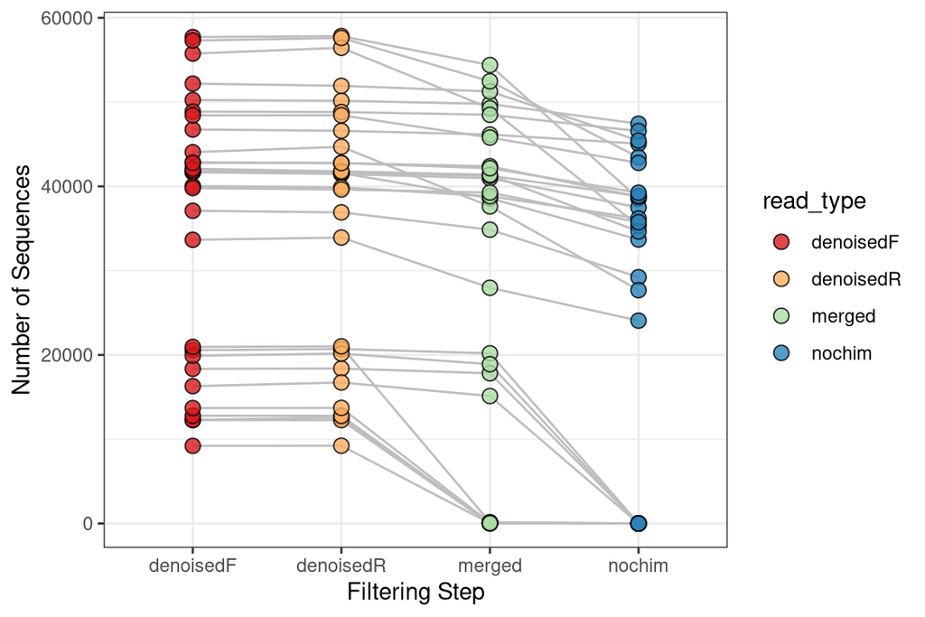

```r
# Plot it!
track_counts_df %>%
  pivot_longer(denoisedF:nochim, names_to = "read_type", values_to = "num_reads") %>%
  mutate(read_type = fct_relevel(read_type, "denoisedF", "denoisedR", "merged", "nochim")) %>%
  ggplot(aes(x = read_type, y = num_reads, fill = read_type)) +
  geom_line(aes(group = sample_names), color = "grey") +
  geom_point(shape = 21, size = 3, alpha = 0.8) +
  scale_fill_brewer(palette = "Spectral") +
  labs(x = "Filtering Step", y = "Number of Sequences") +
  theme_bw()
```

Now, let’s plot the number of sequences that have been maintained in our samples using `geom_histogram()`.

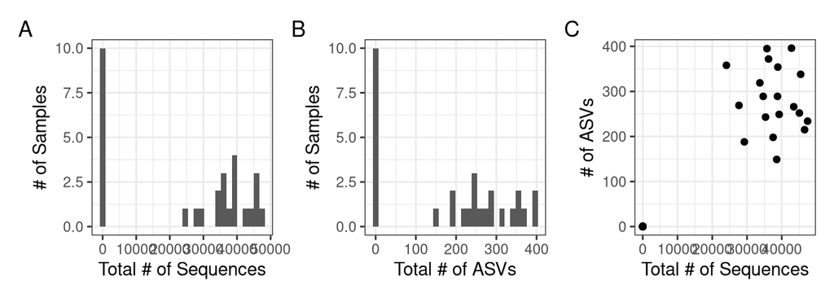

```r
plot_ReadDepth <-
  track_counts_df %>%
  ggplot(aes(x = nochim)) +
  geom_histogram() +
  labs(x = "Total # of Sequences", y = "# of Samples") +
  theme_bw()

# What is the ASV richness per sample?
plot_ASVRichness <-
  track_counts_df %>%
  ggplot(aes(x = num_ASVs)) +
  geom_histogram() +
  labs(x = "Total # of ASVs", y = "# of Samples") +
  theme_bw()

# Now, let's look at the relationship of ASVs and Sequencing depth
plot_ReadDepth_ASVRichness <-
  track_counts_df %>%
  ggplot(aes(x = nochim, y = num_ASVs)) +
  geom_point() +
  labs(x = "Total # of Sequences", y = "# of ASVs") +
  theme_bw()

# Show the plots together
plot_ReadDepth + plot_ASVRichness + plot_ReadDepth_ASVRichness +
    plot_annotation(tag_levels = 'A')
```

# Assign Taxonomy

```r
# Assign up to genus level
taxa_train <-
  assignTaxonomy(noChimeras_ASV_table,
                 refFasta = "/workdir/in_class_data/taxonomy/silva_nr99_v138.2_toGenus_trainset.fa.gz",
                 multithread = n_threads)

# Add the genus/species information
taxa_addSpecies <-
  addSpecies(taxa_train,
              refFasta = "/workdir/in_class_data/taxonomy/silva_v138.2_assignSpecies.fa.gz")

# Inspect the taxonomy
glimpse(taxa_addSpecies) # Note that the rownames are the ASV sequences!
```

```
##  chr [1:1993, 1:7] "Bacteria" "Bacteria" "Bacteria" "Bacteria" "Bacteria" ...
##  - attr(*, "dimnames")=List of 2
##   ..$ : chr [1:1993] "CCGCGGTAATACGTAGGGTGCGAGCGTTAATCGGAATTACTGGGCGTAAAGCGTGCGCAGGCGGTTATGCAAGACAGATGTGAAATCCCCGGGCTCAACCTGGGAACTGCA"| __truncated__ "CCGCGGTAATACGGAGGGTGCAAGCGTTATCCGGATTTATTGGGTTTAAAGGGTCCGTAGGCGGATCTATAAGTCAGTGGTGAAATCTCATAGCTTAACTATGAAACTGCC"| __truncated__ "CCGCGGTAATACGTAGG…
##   ..$ : chr [1:7] "Kingdom" "Phylum" "Class" "Order" ...
```

```r
# Let's removing the ASV sequence rownames for display only
taxa_print <- taxa_addSpecies
rownames(taxa_print) <- NULL
head(taxa_print)
```

```
##      Kingdom    Phylum           Class                 Order
## [1,] "Bacteria" "Pseudomonadota" "Gammaproteobacteria" "Burkholderiales"
## [2,] "Bacteria" "Bacteroidota"   "Bacteroidia"         "Flavobacteriales"
## [3,] "Bacteria" "Pseudomonadota" "Gammaproteobacteria" "Burkholderiales"
## [4,] "Bacteria" "Pseudomonadota" "Gammaproteobacteria" "Burkholderiales"
## [5,] "Bacteria" "Bacteroidota"   "Bacteroidia"         "Flavobacteriales"
## [6,] "Bacteria" "Pseudomonadota" "Gammaproteobacteria" "Methylococcales"
##      Family              Genus           Species
## [1,] "Comamonadaceae"    "Simplicispira" NA
## [2,] "Weeksellaceae"     "Daejeonia"     NA
## [3,] "Comamonadaceae"    "Comamonas"     NA
## [4,] "Comamonadaceae"    "Simplicispira" NA
## [5,] "Weeksellaceae"     "Daejeonia"     NA
## [6,] "Methylomonadaceae" "Methylobacter" NA
```

```r
#View(taxa_print)
```

# Export the Data

## 1. ASV Tables

### Structure of ASV tables

```r
# What's the current format of the ASV table?
head(rownames(noChimeras_ASV_table)) # Samples!
```

```
## [1] "SRR12873300_1_filtered.fastq.gz" "SRR12873301_1_filtered.fastq.gz"
## [3] "SRR12873302_1_filtered.fastq.gz" "SRR12873303_1_filtered.fastq.gz"
## [5] "SRR12873304_1_filtered.fastq.gz" "SRR12873305_1_filtered.fastq.gz"
```

```r
head(colnames(noChimeras_ASV_table)) # ASV Sequences
```

```
## [1] "CCGCGGTAATACGTAGGGTGCGAGCGTTAATCGGAATTACTGGGCGTAAAGCGTGCGCAG…"
## [2] "CCGCGGTAATACGGAGGGTGCAAGCGTTATCCGGATTTATTGGGTTTAAAGGGTCCGTAG…"
## [3] "CCGCGGTAATACGTAGGGTGCGAGCGTTAATCGGAATTACTGGGCGTAAAGCGTGCGCAG…"
## [4] "CCGCGGTAATACGTAGGGTGCGAGCGTTAATCGGAATTACTGGGCGTAAAGCGTGCGCAG…"
## [5] "CCGCGGTAATACGGAGGGTGCAAGCGTTATCCGGATTTATTGGGTTTAAAGGGTCCGTAG…"
## [6] "CCGCGGTAATACGGAGGGTGCAAGCGTTAATCGGAATTACTGGGCGTAAAGCGTGCGTAG…"
```

```r
# Therefore, we need to transpose the matrix
final_ASV_table_withSeqs <- t(noChimeras_ASV_table)

# Intuition check
head(rownames(final_ASV_table_withSeqs)) # ASV Sequences
```

```
## [1] "CCGCGGTAATACGTAGGGTGCGAGCGTTAATCGGAATTACTGGGCGTAAAGCGTGCGCAG…"
## [2] "CCGCGGTAATACGGAGGGTGCAAGCGTTATCCGGATTTATTGGGTTTAAAGGGTCCGTAG…"
## [3] "CCGCGGTAATACGTAGGGTGCGAGCGTTAATCGGAATTACTGGGCGTAAAGCGTGCGCAG…"
## [4] "CCGCGGTAATACGTAGGGTGCGAGCGTTAATCGGAATTACTGGGCGTAAAGCGTGCGCAG…"
## [5] "CCGCGGTAATACGGAGGGTGCAAGCGTTATCCGGATTTATTGGGTTTAAAGGGTCCGTAG…"
## [6] "CCGCGGTAATACGGAGGGTGCAAGCGTTAATCGGAATTACTGGGCGTAAAGCGTGCGTAG…"
```

```r
head(colnames(final_ASV_table_withSeqs)) # Sample names
```

```
## [1] "SRR12873300_1_filtered.fastq.gz" "SRR12873301_1_filtered.fastq.gz"
## [3] "SRR12873302_1_filtered.fastq.gz" "SRR12873303_1_filtered.fastq.gz"
## [5] "SRR12873304_1_filtered.fastq.gz" "SRR12873305_1_filtered.fastq.gz"
```

### Names in ASV tables

#### Fix Sample Names

```r
# Remember at the top of the file we created a vector of sample names
head(sample_names)
```

```
## [1] "SRR12873300" "SRR12873301" "SRR12873302" "SRR12873303" "SRR12873304"
## [6] "SRR12873305"
```

```r
# Let's check with the actual column names
head(colnames(final_ASV_table_withSeqs)) # Sample names
```

```
## [1] "SRR12873300_1_filtered.fastq.gz" "SRR12873301_1_filtered.fastq.gz"
## [3] "SRR12873302_1_filtered.fastq.gz" "SRR12873303_1_filtered.fastq.gz"
## [5] "SRR12873304_1_filtered.fastq.gz" "SRR12873305_1_filtered.fastq.gz"
```

```r
# And then apply our sample name script to check, too
head(sapply(strsplit(colnames(final_ASV_table_withSeqs), "_"), `[`,1)) # Looks good!
```

```
## [1] "SRR12873300" "SRR12873301" "SRR12873302" "SRR12873303" "SRR12873304"
## [6] "SRR12873305"
```

```r
# Now, add a break in the script break if this isn't true!
# Let's make sure the sample names match the file names in the matrix.
stopifnot(sapply(strsplit(colnames(final_ASV_table_withSeqs), "_"), `[`,1) == sample_names)

# Now, we've done some checks to prove to ourselves there will be no silent errors,
# Let's rename!
colnames(final_ASV_table_withSeqs) <- sample_names
head(colnames(final_ASV_table_withSeqs))
```

```
## [1] "SRR12873300" "SRR12873301" "SRR12873302" "SRR12873303" "SRR12873304"
## [6] "SRR12873305"
```

#### Rename ASVs

```r
# Give headers more manageable names
# First pull the ASV sequences from the rownames
ASV_seqs <- rownames(final_ASV_table_withSeqs)
ASV_seqs[1:5]
```

```
## [1] "CCGCGGTAATACGTAGGGTGCGAGCGTTAATCGGAATTACTGGGCGTAAAGCGTGCGCAG…"
## [2] "CCGCGGTAATACGGAGGGTGCAAGCGTTATCCGGATTTATTGGGTTTAAAGGGTCCGTAG…"
## [3] "CCGCGGTAATACGTAGGGTGCGAGCGTTAATCGGAATTACTGGGCGTAAAGCGTGCGCAG…"
## [4] "CCGCGGTAATACGTAGGGTGCGAGCGTTAATCGGAATTACTGGGCGTAAAGCGTGCGCAG…"
## [5] "CCGCGGTAATACGGAGGGTGCAAGCGTTATCCGGATTTATTGGGTTTAAAGGGTCCGTAG…"
```

```r
# How many ASVs?
num_ASVs <- dim(final_ASV_table_withSeqs)[1] # select the number of rows
num_ASVs
```

```
## [1] 1993
```

```r
# Make an empty vector the length of the number of ASVs,
# which is where we will place the new operational ASV names
ASV_headers <- vector(num_ASVs, mode = "character")

# Let's mae sure we have an empty vector!
ASV_headers[1:5]
```

```
## [1] "" "" "" "" ""
```

```r
length(ASV_headers) # looks good!
```

```
## [1] 1993
```

```r
# Now, let's create a vector with ASV numbers
# loop through vector and fill it in with ASV names
for (i in 1:num_ASVs) {
  # Add leading zero to ASV name so they print in correct order.
  ASV_number <- sprintf("%04d", i)
  # Now, rename each spot in the ASV header vector as we loop through the for loop
  ASV_headers[i] <- paste(">ASV", ASV_number, sep = "_")
}

# Intuition check
ASV_headers[1:5]
```

```
## [1] ">ASV_0001" ">ASV_0002" ">ASV_0003" ">ASV_0004" ">ASV_0005"
```

```r
# Create a new ASV table, which will have the ASV numbers as names
# View(noChimeras_ASV_table) # To view the table
final_ASV_table <- final_ASV_table_withSeqs
glimpse(final_ASV_table)
```

```
##  int [1:1993, 1:29] 298 18 0 241 0 10263 0 0 1616 7852 ...
##  - attr(*, "dimnames")=List of 2
##   ..$ : chr [1:1993] "CCGCGGTAATACGTAGGGTGCGAGCGTTAATCGGAATTACTGGGCGTAAAGCGTGCGCAGGCGGTTATGCAAGACAGATGTGAAATCCCCGGGCTCAACCTGGGAACTGCA"| __truncated__ "CCGCGGTAATACGGAGGGTGCAAGCGTTATCCGGATTTATTGGGTTTAAAGGGTCCGTAGGCGGATCTATAAGTCAGTGGTGAAATCTCATAGCTTAACTATGAAACTGCC"| __truncated__ "CCGCGGTAATACGTAGG…
##   ..$ : chr [1:29] "SRR12873300" "SRR12873301" "SRR12873302" "SRR12873303" ...
```

```r
## Replace the ASV seqs with the ASV numbers
row.names(final_ASV_table) <- sub(">", "", ASV_headers)
final_ASV_table[1:5, 1:5]
```

```
##          SRR12873300 SRR12873301 SRR12873302 SRR12873303 SRR12873304
## ASV_0001         298         696         502        9232        5583
## ASV_0002          18          12           0          41         103
## ASV_0003           0           0           0        2428        6703
## ASV_0004         241         430         415        6470        4070
## ASV_0005           0           0          27          25          62
```

```r
#View(final_ASV_table) # To view the table
```

### Write the ASV Tables!

```r
# 1. Write count table with ASV sequence names
write.table(final_ASV_table_withSeqs,
            file = "data/ASV_table_withSeqNames.tsv",
            sep = "\t", quote = FALSE, col.names = NA)

# 2. Write count table with ASV numbered names (e.g. ASV_1, ASV_2, etc)
write.table(final_ASV_table,
            file = "data/ASV_table.tsv",
            sep = "\t", quote = FALSE, col.names = NA)
```

## 2. ASV Fasta File

### Write the ASV Fasta File

```r
# Let's take our asv_headers
head(ASV_headers, n = 2)
```

```
## [1] ">ASV_0001" ">ASV_0002"
```

```r
# And combine it with their sequences
head(ASV_seqs, n = 2)
```

```
## [1] "CCGCGGTAATACGTAGGGTGCGAGCGTTAATCGGAATTACTGGGCGTAAAGCGTGCGCAG…"
## [2] "CCGCGGTAATACGGAGGGTGCAAGCGTTATCCGGATTTATTGGGTTTAAAGGGTCCGTAG…"
```

```r
# Combine in a fasta format with the cbind() function
ASV_fasta <- c(rbind(ASV_headers, ASV_seqs))
head(ASV_fasta, n = 4)
```

```
## [1] ">ASV_0001"
## [2] "CCGCGGTAATACGTAGGGTGCGAGCGTTAATCGGAATTACTGGGCGTAAAGCGTGCGCAG…"
## [3] ">ASV_0002"
## [4] "CCGCGGTAATACGGAGGGTGCAAGCGTTATCCGGATTTATTGGGTTTAAAGGGTCCGTAG…"
```

```r
# Then, let's write it to a fasta file!
# This will be our reference later on for which seq matches which ASV
write(ASV_fasta, "data/ASVs.fasta")
```

## 3. Taxonomy Table

### Reformat Taxonomy

```r
# Inspect the taxonomy table
dim(taxa_addSpecies) # ASVs are in rows and Kingdom, Phylum, etc in Columns
```

```
## [1] 1993    7
```

```r
colnames(taxa_addSpecies) # Column names are Linnean Taxonomy
```

```
## [1] "Kingdom" "Phylum"  "Class"   "Order"   "Family"  "Genus"   "Species"
```

```r
head(rownames(taxa_addSpecies), n = 2) # ASV names are rownames
```

```
## [1] "CCGCGGTAATACGTAGGGTGCGAGCGTTAATCGGAATTACTGGGCGTAAAGCGTGCGCAG…"
## [2] "CCGCGGTAATACGGAGGGTGCAAGCGTTATCCGGATTTATTGGGTTTAAAGGGTCCGTAG…"
```

```r
class(taxa_addSpecies) # Character matrix
```

```
## [1] "matrix" "array"
```

```r
##### Prepare tax table
# 1. Add the ASV sequences from the rownames to a column
new_tax_table <-
  taxa_addSpecies%>%
  as.data.frame() %>%
  rownames_to_column(var = "ASVseqs")

# Intuition check
glimpse(new_tax_table)
```

```
## Rows: 1,993
## Columns: 8
## $ ASVseqs <chr> "CCGCGGTAATACGTAGGGTGCGAGCGTTAATCGGAATTACTGGGCGTAAAGCGTGCGCAGG…
## $ Kingdom <chr> "Bacteria", "Bacteria", "Bacteria", "Bacteria", "Bacteria", "B…
## $ Phylum  <chr> "Pseudomonadota", "Bacteroidota", "Pseudomonadota", "Pseudomon…
## $ Class   <chr> "Gammaproteobacteria", "Bacteroidia", "Gammaproteobacteria", "…
## $ Order   <chr> "Burkholderiales", "Flavobacteriales", "Burkholderiales", "Bur…
## $ Family  <chr> "Comamonadaceae", "Weeksellaceae", "Comamonadaceae", "Comamona…
## $ Genus   <chr> "Simplicispira", "Daejeonia", "Comamonas", "Simplicispira", "D…
## $ Species <chr> NA, NA, NA, NA, NA, NA, NA, NA, NA, "ucrainicus", NA, NA, NA, …
```

```r
# IMPORTANT! Let's do our intuition check
# This is where we ensure we don't mix up the ASV names!
stopifnot(new_tax_table$ASVseqs == rownames(final_ASV_table_withSeqs))

# Now let's add the ASV names
rownames(new_tax_table) <- rownames(final_ASV_table)
head(new_tax_table)
```

```
##                                                                                                                                                                                                                                                                                                          …
## ASV_0001   CCGCGGTAATACGTAGGGTGCGAGCGTTAATCGGAATTACTGGGCGTAAAGCGTGCGCAG…
## ASV_0002    CCGCGGTAATACGGAGGGTGCAAGCGTTATCCGGATTTATTGGGTTTAAAGGGTCCGTAG…
## ASV_0003   CCGCGGTAATACGTAGGGTGCGAGCGTTAATCGGAATTACTGGGCGTAAAGCGTGCGCAG…
## ASV_0004   CCGCGGTAATACGTAGGGTGCGAGCGTTAATCGGAATTACTGGGCGTAAAGCGTGCGCAG…
## ASV_0005    CCGCGGTAATACGGAGGGTGCAAGCGTTATCCGGATTTATTGGGTTTAAAGGGTCCGTAG…
## ASV_0006 CCGCGGTAATACGGAGGGTGCAAGCGTTAATCGGAATTACTGGGCGTAAAGCGTGCGTAG…
##           Kingdom         Phylum               Class            Order
## ASV_0001 Bacteria Pseudomonadota Gammaproteobacteria  Burkholderiales
## ASV_0002 Bacteria   Bacteroidota         Bacteroidia Flavobacteriales
## ASV_0003 Bacteria Pseudomonadota Gammaproteobacteria  Burkholderiales
## ASV_0004 Bacteria Pseudomonadota Gammaproteobacteria  Burkholderiales
## ASV_0005 Bacteria   Bacteroidota         Bacteroidia Flavobacteriales
## ASV_0006 Bacteria Pseudomonadota Gammaproteobacteria  Methylococcales
##                     Family         Genus Species
## ASV_0001    Comamonadaceae Simplicispira    <NA>
## ASV_0002     Weeksellaceae     Daejeonia    <NA>
## ASV_0003    Comamonadaceae     Comamonas    <NA>
## ASV_0004    Comamonadaceae Simplicispira    <NA>
## ASV_0005     Weeksellaceae     Daejeonia    <NA>
## ASV_0006 Methylomonadaceae Methylobacter    <NA>
```

```r
### Final prep of tax table. Add new column with ASV names
ASV_tax_table <-
  new_tax_table %>%
  # add rownames from count table for phyloseq handoff
  mutate(ASV = rownames(final_ASV_table)) %>%
  # Reorder the columns
  dplyr::select(Kingdom, Phylum, Class, Order, Family, Genus, Species, ASV, ASVseqs)

# Assign the rownames, which is required by phyloseq
rownames(ASV_tax_table) <- ASV_tax_table$ASV

# Take a quick look
glimpse(ASV_tax_table)
```

```
## Rows: 1,993
## Columns: 9
## $ Kingdom <chr> "Bacteria", "Bacteria", "Bacteria", "Bacteria", "Bacteria", "B…
## $ Phylum  <chr> "Pseudomonadota", "Bacteroidota", "Pseudomonadota", "Pseudomon…
## $ Class   <chr> "Gammaproteobacteria", "Bacteroidia", "Gammaproteobacteria", "…
## $ Order   <chr> "Burkholderiales", "Flavobacteriales", "Burkholderiales", "Bur…
## $ Family  <chr> "Comamonadaceae", "Weeksellaceae", "Comamonadaceae", "Comamona…
## $ Genus   <chr> "Simplicispira", "Daejeonia", "Comamonas", "Simplicispira", "D…
## $ Species <chr> NA, NA, NA, NA, NA, NA, NA, NA, NA, "ucrainicus", NA, NA, NA, …
## $ ASV     <chr> "ASV_0001", "ASV_0002", "ASV_0003", "ASV_0004", "ASV_0005", "A…
## $ ASVseqs <chr> "CCGCGGTAATACGTAGGGTGCGAGCGTTAATCGGAATTACTGGGCGTAAAGCGTGCGCAGG…
```

```r
# Intution check
stopifnot(ASV_tax_table$ASV == rownames(ASV_tax_table),
          rownames(ASV_tax_table) == rownames(ASV_tax_table))
```

### Write the Taxonomy Table

```r
# Write the table
write.table(ASV_tax_table,
            file = "data/ASV_taxonomy.tsv",
            sep = "\t", quote = FALSE, col.names = NA)
```

## 4. Sample Data

```r
# And save the track_counts_df a R object, which we will merge with metadata information in the next step of the analysis in nalysis/02_Taxonomic_Assignment.
save(track_counts_df, file = "data/track_read_counts.RData")
```

# Final info for Reproducibility

## Check Render Time

```r
# Take the time now that we are at the end of the script
end_time <- Sys.time()
end_time
```

```
## [1] "2025-03-10 17:30:47 EDT"
```

```r
# Echo the elapsed time
elapsed_time <- round((end_time - start_time), 3)
elapsed_time
```

```
## Time difference of 7.348 mins
```